# Galloway: Math 5131 Final Project

## Intro

### Background

In operation of fired steam boilers, the water reservoir for production of steam is called the steam drum. Safety and reliability concerns require that the level of liquid in this reservoir be kept under tight control as too high a level will cause liquid phase water to flood the steam delivery network, and too low a level will result in the boiler tubes, which absorb the heat from the furnace/firebox section, to become exposed and fail due to temperatures exceeding design.  
The level in the drum displays interesting dynamics under certain circumstances, adding water from the feed system to make up the mass lost through steam production can sometimes actually cause the level of the drum to decrease for a period of time before moving in the expected direction. Under the opposite conditions where steam is removed quicker than makeup water is added the liquid in the steam drum will increase prior to moving in the expected direction of decreasing. This phenomenon is called “boiler drum shrink and swell” and is the topic of interest.

### Topic

During normal operations of industrial boilers, it is difficult if not impossible to examine the effects of varying inputs and outputs to the system individually. Here we examine the effects of mass and energy imbalances on the liquid and vapor phases of the steam drum for a boiler model tailored to a region of pressures typifying industrial applications. This includes:

- Positive and Negative System Mass Imbalances with the Energy Balance Held Equal
- Positive and Negative System Energy Imbalances with the Mass Balance Held Equal

The pressure region selected is 1250 psia to 1750 psia.

## Model Development

### Boiler Drum Level Physical System Definition

[figure not shown]

General drum-boiler schematic.

#### Simplified System

To simplify the system we will omit the riser section (aka upcomers), downcomers and mud drum drawing a system boundary around just the drum portion of the process.

[figure not shown]

#### Variable Definitions

$\dot{H_{FG}}$ = Enthalpy Flow From Furnace Combustion $\big[\frac{btu}{s}\big]$  
$\dot{M_{FW}}$ = Mass Flow of Feed Water $\big[ psia \big]$  
$H_{FW}$ = Specific Enthalpy of Boiler Feed Water From Pump $\big[ \frac{btu}{lb}\big]$  
$M_L$ = Mass of Water in Boiler Drum $\big[ lbs \big]$  
$\rho_L$ = Density of Liquid in Boiler Drum $\big[\frac{lbs}{ft^3}\big]$  
$c_L$ = Specific Heat Capacity of Water $\big[\frac{btu}{lb- ^{\circ} F}\big]$  
$\dot{M_{out}}$ = Mass Flow of Steam to Process $\big[\frac{lbs}{s}\big]$  
$H_{S}$ = Specific Enthalpy of Steam in the Boiler Drum $\big[ \frac{btu}{lb}\big]$  
$V_D$ = Total Volume of Boiler Drum $\big[ ft^3 \big]$  
$L$ = Length of Boiler Drum $\big[ ft \big]$  
$D$ = Diameter of Boiler Drum $\big[ ft \big]$  
$M_{S}$ = Mass of Steam in Boiler Drum $\big[lbs\big]$  
$V_S$ = Volume of Steam in Boiler Drum $\big[ ft^3 \big]$  
$P$ = Pressure in Boiler Drum $\big[ psia \big]$  
$T$ = Temperature of Contents of Boiler Drum $\big[ ^{\circ} F \big]$  
$\dot{M_{V}}$ = Mass Flow of Steam from Liquid Phase to Vapor Phase $\big[ psia \big]$

### Fitting Curves to Tabular Data

```python
from iapws import IAPWS97
from scipy.optimize import curve_fit
from scipy import interpolate
from scipy.integrate import odeint
import pandas as pd
import numpy as np
import matplotlib.pyplot as plt

fileName = 'SpecificHeatTable.xlsx'   # specific heat values
tableRef = 'https://www.engineeringtoolbox.com/specific-heat-capacity-water-d_660.html'

#  Read Table
try:
    rawTable = pd.read_excel(fileName)
    print('Table Read Successful')
except:
    print(fileName + ' Not Found')

'''Build Interpolated Function from Table'''
display(tableRef,rawTable)
cols = rawTable.columns
CpFunct = interpolate.interp1d(list(rawTable[cols[0]]), list(rawTable[cols[-2]]))
```

```
Table Read Successful
```

```
'https://www.engineeringtoolbox.com/specific-heat-capacity-water-d_660.html'
```

|  | [°F] | [Btu(IT)/(mol °R)] | [Btu(IT)/(lbm °F)] | [kJ/(kg K)] | [Btu(IT)/kmol °R] | [Btu(IT)/lbm °F] | [kJ/kg K] |
| --- | --- | --- | --- | --- | --- | --- | --- |
| 0 | 40 | 39.9 | 1.005 | 4.208 | 39.916 | 1.005 | 4.208 |
| 1 | 50 | 39.8 | 1.001 | 4.191 | 39.801 | 1.002 | 4.196 |
| 2 | 60 | 39.6 | 0.996 | 4.169 | 39.739 | 1.001 | 4.189 |
| 3 | 80 | 39.2 | 0.986 | 4.128 | 39.660 | 0.999 | 4.181 |
| 4 | 100 | 38.7 | 0.975 | 4.082 | 39.643 | 0.998 | 4.179 |
| 5 | 120 | 38.3 | 0.963 | 4.033 | 39.662 | 0.999 | 4.181 |
| 6 | 140 | 37.7 | 0.950 | 3.977 | 39.702 | 1.000 | 4.185 |
| 7 | 160 | 37.2 | 0.937 | 3.923 | 39.761 | 1.001 | 4.191 |
| 8 | 180 | 36.7 | 0.923 | 3.865 | 39.835 | 1.003 | 4.199 |
| 9 | 200 | 36.1 | 0.909 | 3.805 | 39.927 | 1.005 | 4.209 |
| 10 | 212 | 35.7 | 0.900 | 3.768 | 39.993 | 1.007 | 4.216 |
| 11 | 220 | 35.5 | 0.895 | 3.745 | 40.042 | 1.008 | 4.221 |
| 12 | 240 | 35.0 | 0.880 | 3.686 | 40.186 | 1.012 | 4.236 |
| 13 | 260 | 34.4 | 0.867 | 3.629 | 40.364 | 1.016 | 4.255 |
| 14 | 280 | 33.9 | 0.854 | 3.574 | 40.580 | 1.022 | 4.278 |
| 15 | 300 | 33.4 | 0.841 | 3.522 | 40.838 | 1.028 | 4.305 |
| 16 | 350 | 32.3 | 0.813 | 3.404 | 41.685 | 1.050 | 4.394 |
| 17 | 400 | 31.3 | 0.789 | 3.302 | 42.902 | 1.080 | 4.522 |
| 18 | 450 | 30.4 | 0.767 | 3.209 | 44.009 | 1.108 | 4.639 |
| 19 | 500 | 29.7 | 0.748 | 3.130 | 47.296 | 1.191 | 4.986 |
| 20 | 550 | 28.8 | 0.725 | 3.035 | 51.318 | 1.292 | 5.410 |
| 21 | 600 | 28.3 | 0.713 | 2.987 | 59.690 | 1.503 | 6.292 |
| 22 | 625 | 28.4 | 0.716 | 2.997 | 66.611 | 1.677 | 7.022 |
| 23 | 650 | 28.9 | 0.728 | 3.047 | 82.851 | 2.086 | 8.734 |
| 24 | 675 | 29.9 | 0.754 | 3.156 | 126.670 | 3.189 | 13.353 |

```python
"""
####################
Fit Curve values for region of pressures in industrial applications.

#########################
IAWPS 97 Docs
Dict with calculated properties. The available properties are:

T: Saturated temperature, [K]
P: Saturated pressure, [MPa]
x: Vapor quality, [-]
v: Specific volume, [m³/kg]
h: Specific enthalpy, [kJ/kg]
s: Specific entropy, [kJ/kgK]

"""
# Constants
PSI2MPA = 0.101325/14.69
MPA2PSI = 1./PSI2MPA
BAR2MPA = 0.1
MPA2BAR = 1./BAR2MPA
KJKG2BTULB = 0.42992
BTULB2KJKG = 1./ KJKG2BTULB
KJKGK2BTULBR = 0.238846
BTULBR2KJKGK = 1./KJKGK2BTULBR
LBGAL2KGCM = 119.826
KGCM2LBGAL = 1./LBGAL2KGCM
KGS2LBHR = 7937 # kg/s steam to lb/hr
LBHR2KGS = 1/KGS2LBHR
KGCM2LBCF = 0.06248
Rsteam = 85.856 # ft-lbf/lbm-R
SCFPERLBMOL = 379.3
LIQUID = 0.
SATSTEAM = 1.

# Functions
def F2K(f):
    """ Fahrenheit to Kelvin """
    return 5./9.*(f + 459.67)

def K2F(k):
    """ Kelvin to Fahrenheit """
    return k*9./5. - 459.67
def C2K(c):
    """ Celcius to Kelvin """
    return c + 273.15
def K2C(k):
    """ Kelvin to Celcius """
    return k - 273.15

def psia(p):
    """ PSIG to PSIA """
    return p + 14.69

def psig(p):
    """ PSIA to PSIG """
    return p - 14.69

def F2R(f):
    '''Fahrenheit to Rankine'''
    return f + 459.67

def R2F(r):
    '''Rankine to Fahrenheit'''
    return r - 459.67
#=====================================================
# Generate steam table for region of interest
region = (1250.,1750.)      # Pressure region of interst [PSIA]
n = 1000                # number of points
P_D = np.linspace(*region,n)
sat_steam = []
sat_liquid = []

"""Build Tables from IAPWS97 Package"""
# Need curves rho_l(T), Tsat(P), Hstm(T)
Tsat = []   # Saturation Temperature at a given Pressure
rho_l = []  # density of liquid at Temp
Hstm = []   # Specific Enthalpy of Steam at Given T

for p in P_D:
    sat_steam.append(IAPWS97(P = p*PSI2MPA, x = SATSTEAM))
    sat_liquid.append(IAPWS97(P = p*PSI2MPA, x = LIQUID))
    Tsat.append(K2F(sat_liquid[-1].T))
    rho_l.append(KGCM2LBCF/sat_liquid[-1].v)
    Hstm.append(sat_steam[-1].h*KJKG2BTULB)

""" Fit Curves to Table Data from IAPWS and Other Table Values """

beta = np.polyfit(Tsat,rho_l,1)
lam = np.polyfit(Tsat,Hstm,1)
alpha = np.polyfit(Tsat,CpFunct(Tsat),2)
gamma = np.polyfit(P_D,Tsat,1)

fitTsat = []
fitRho_l = []
fitHstm = []
fitCp   = []


# Create Function to Evaluate Polyfit of Any Order
def evalPoly(coef,x):
    y = 0
    order = len(coef) - 1
    for i in range(len(coef)):
        y = y + coef[i]*x**(order - i)
    return y



for i in range(len(P_D)):
    fitTsat.append(evalPoly(gamma,P_D[i]))
    fitRho_l.append(evalPoly(beta,Tsat[i]))
    fitHstm.append(evalPoly(lam,Tsat[i]))
    fitCp.append(evalPoly(alpha,Tsat[i]))

""" Build tables of Curve Fit Parameters """
params = [beta,lam,alpha,gamma]
ind = ['Saturated Liquid Density vs Saturation Temp (Poly)',
       'Steam Specific Enthalpy vs Saturation Temp (Poly)',
       'Specific Heat Capacity of Water vs Saturation Temp (Poly)',
       'Steam-Liquid Saturation Temperature vs Pressure (Poly)']
# build column headers
order = 0
for coef in params:
    order = max(order,len(coef))
col = []
for i in range(order):
    col.append('p' + str(order -1 - i))

# Pad parameter matrices for display

for i in range(len(params)):
    while (len(params[i])<len(col)):
        params[i] = np.insert(params[i],0,0)

# Build the Table
df = pd.DataFrame(params,columns= col, index=ind)
print('Parameters Resulting From Curve Fitting')
display(df)
```

```
Parameters Resulting From Curve Fitting
```

|  | p2 | p1 | p0 |
| --- | --- | --- | --- |
| Saturated Liquid Density vs Saturation Temp (Poly) | 0.000000 | -0.080402 | 90.561163 |
| Steam Specific Enthalpy vs Saturation Temp (Poly) | 0.000000 | -0.624383 | 1540.647940 |
| Specific Heat Capacity of Water vs Saturation Temp (Poly) | 0.000052 | -0.057233 | 16.979969 |
| Steam-Liquid Saturation Temperature vs Pressure (Poly) | 0.000000 | 0.089223 | 462.004416 |

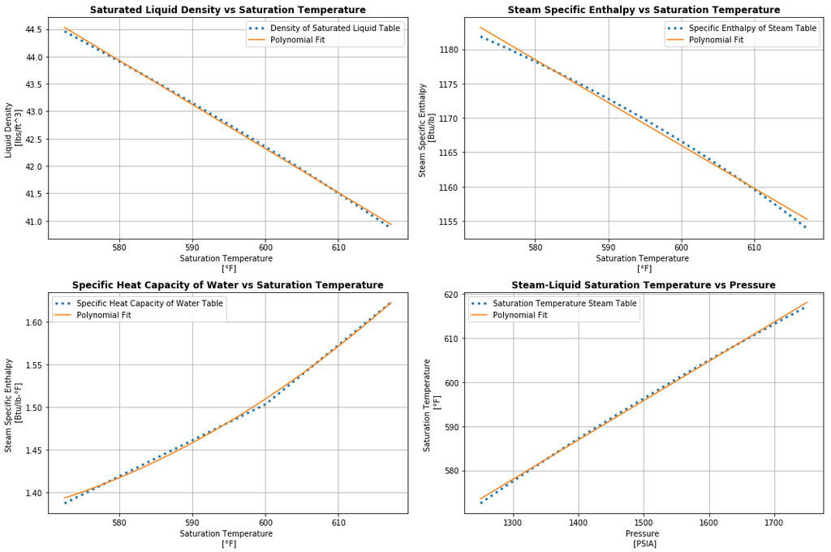

```python
""" Plot Look Up Table and Fitted Curve """

fig= plt.figure(figsize=(15, 10))
plt.subplot(221)
_ = plt.plot(Tsat,rho_l, linestyle = ':',linewidth=3, label='Density of Saturated Liquid Table')
_ = plt.plot(Tsat,fitRho_l, label='Polynomial Fit')

plt.title('Saturated Liquid Density vs Saturation Temperature',fontweight='bold')
plt.ylabel('Liquid Density \n [lbs/ft^3]')
plt.xlabel('Saturation Temperature \n [°F]')
plt.legend(loc='best')
plt.grid()

plt.subplot(222)
_ = plt.plot(Tsat,Hstm, linestyle = ':',linewidth=3, label='Specific Enthalpy of Steam Table')
_ = plt.plot(Tsat,fitHstm, label='Polynomial Fit')

plt.title('Steam Specific Enthalpy vs Saturation Temperature',fontweight='bold')
plt.ylabel('Steam Specific Enthalpy \n [Btu/lb]')
plt.xlabel('Saturation Temperature \n [°F]')
plt.legend(loc='best')
plt.grid()

plt.subplot(223)
_ = plt.plot(Tsat,CpFunct(Tsat), linestyle = ':',linewidth=3, label='Specific Heat Capacity of Water Table')
_ = plt.plot(Tsat,fitCp, label='Polynomial Fit')

plt.title('Specific Heat Capacity of Water vs Saturation Temperature',fontweight='bold')
plt.ylabel('Steam Specific Enthalpy \n [Btu/lb-°F]')
plt.xlabel('Saturation Temperature \n [°F]')
plt.legend(loc='best')
plt.grid()

plt.subplot(224)
_ = plt.plot(P_D,Tsat, linestyle = ':',linewidth=3, label='Saturation Temperature Steam Table')
_ = plt.plot(P_D,fitTsat, label='Polynomial Fit')

plt.title('Steam-Liquid Saturation Temperature vs Pressure',fontweight='bold')
plt.ylabel('Saturation Temperature \n [°F]')
plt.xlabel('Pressure \n [PSIA]')
plt.legend(loc='best')
plt.grid()
plt.tight_layout()
```

### Boiler Drum First Principles Modeling

#### Assumptions

- Thermodynamic equilibrium exists between the liquid and vapor phases at all times. The consequence of which is the liquid and vapor temperature are equal and the energy balance for the vapor phase is not necessary. (Reference: Modeling and Simulation in Chemical Engineering, Franks 1972)
- Initial conditions will be such that the system is already at saturation temperature and there will be no heat-up stage required.

#### System Equations

Working from the mass and engery balances, other physical relationships and the curves fit to various table values for the region of interest we have,

##### Mass and Energy Balances

\begin{align} \frac{d \big(c_L M_L T\big)}{dt} &= H_{FW}\dot{M_{FW}} + \dot{H_{FG}} - H_S\dot{M_V} \label{1} \tag{1} \\[10pt] \frac{d M_L}{dt} &= \dot{M_{FW}} - \dot{M_V} \label{2} \tag{2} \\[10pt] \frac{d M_S}{dt} &= \dot{M_V}(T) - \dot{M_{out}} \label{3} \tag{3} \\[10pt] \end{align}

##### Curve Fit Equations

\begin{align} c_L(T) &= \alpha_2T^2 + \alpha_1T + \alpha_0 \label{4} \tag{4} \\[10pt] \rho_L(T) &= \beta_1T + \beta_0 \label{5} \tag{5} \\[10pt] H_S(T) &= \lambda_1T + \lambda_0 \label{6} \tag{6} \\[10pt] T(P) = \gamma_1P + \gamma_0 &\implies P(T) = \frac{T - \gamma_0}{\gamma_1}\label{7} \tag{7} \\[10pt] \end{align}

##### Physical and Thermodynamic Relationships

\begin{align} V_S &= V_D - \frac{M_L}{\rho_L} \label{8} \tag{8} \\[10pt] c_1 P V_S = M_SR_S(T + c_2) &\implies M_L(M_S,T) = \rho_L(T)\bigg(V_D - \frac{M_S R_S (T + c_2)}{c_1 P(T)}\bigg)\label{9} \tag{9} \\[10pt] \dot{M_V}(T) = \frac{\dot{H_{FG}}}{H_S(T) - H_{FW}} &\implies \frac{\dot{H_{FG}}}{\lambda_1T + \lambda_0 - H_{FW}} \label{10} \tag{10} \\[10pt] \end{align}

##### Solving For a Final System in $T, Ms$

Substituting eq. $\ref{2}$, eq. $\ref{5}$, eq. $\ref{7}$ and eq. $\ref{9}$ into equation eq. $\ref{1}$ gives,

\begin{align} \frac{d \big(c_L M_L T\big)}{dt} &= H_{FW}\dot{M_{FW}} + \dot{H_{FG}} - H_S\dot{M_V} \tag{1} \\[10pt] \text{Let, $f(T) = c_L(T)*T$, then,}&\\[10pt] \implies \frac{d \big(M_Lf(T)\big)}{dt} &= M_L(M_S,T)\frac{d f(T)}{dT}\frac{dT}{dt} + f(T)\frac{dM_L}{dt} \\[10pt] &= M_L(M_S,T)\frac{d f(T)}{dT}\frac{dT}{dt} + f(T)\big( \dot{M_{FW}} - \dot{M_V}(T)\big)\\[10pt] \text{Now,} \\[10pt] f(T) = c_L(T)*T &= \big( \alpha_2T^2 + \alpha_1T + \alpha_0 \big)T = \alpha_2T^3 + \alpha_1T^2 + \alpha_0T \label{11} \tag{11}\\[10pt] \text{and, } \frac{d f(T)}{dT} &= 3\alpha_2T^2 + 2\alpha_1T + \alpha_0 \label{12} \tag{12}\\[10pt] \text{And finally,} \\[10pt] \frac{dT}{dt} &= \frac{H_{FW}\dot{M_{FW}} + \dot{H_{FG}} - H_S(T)\dot{M_V}(T) - f(T)\big( \dot{M_{FW}} - \dot{M_V}(T)\big)}{M_L(M_S,T)\frac{d f(T)}{dT}} \label{1a} \tag{1a} \\[10pt] \end{align}

Thus from the synthesis of the system equations we arrive at a nonlinear, autonomous system of differential equations in $M_S$ and $T$. All other variables of interest can be calculated after this system is solved.

### Final System

\begin{align} &\boxed{\frac{dT}{dt} = \frac{H_{FW}\dot{M_{FW}} + \dot{H_{FG}} - H_S(T)\dot{M_V}(T) - f(T)\big( \dot{M_{FW}} - \dot{M_V}(T)\big)}{M_L(M_S,T)\frac{d f(T)}{dT}}} \tag{1a} \\[10pt] &\boxed{\frac{d M_S}{dt} = \dot{M_V}(T) - \dot{M_{out}}} \tag{3} \\[10pt] \end{align}

## Simulation

### Boiler Dimensions and Initial Conditions

First, to check the model, we fix initial conditions t o match a boiler the student has worked on in the past. With the boiler at a quiescent point, the energy input from $\dot{H_{FG}}$ will be equal to the amount of energy to heat the incoming feedwater to saturation temperature, plus the heat required to vaporize the liquid to replace the outgoing steam. This will allow us to compute a suitable $\dot{H_{FG}}$ for balanced operation. The masses are trivial to balance.

[figure not shown]

Ammonia Plant: Enid, Oklahoma

#### Constructing Functions for the Systems as Derived

```python
'''
=============================================
Parameters and Fucntion Definitions
=============================================
'''
###########################
# System Parameters
D = 6. # drum diameter [feet]
L = 42. # drum length [feet]
Vd = np.pi*(D/2)**2*L # total drum volume [ft^3]

PSI2PSF = 144.   # Converstion Factor psi to psf
##########################
# Define Functions for Fit Curves and others

# Equation 5
def rho(T):
    return beta[0]*T + beta[1]

# Equation 6
def Hs(T):
    return lam[0]*T + lam[1]

# Equation 7 and the inversion
def T_of_P(P):
    return gamma[0]*P + gamma[1]

def P_of_T(T):
    return (T-gamma[1])/gamma[0]

# Equation 9
def ML(Ms,T):
    return rho(T)*(Vd - Ms*Rsteam*F2R(T)/P_of_T(T)/PSI2PSF)

# Equation 10
def Mv(T,Hfg,Hfw):
    return Hfg/(Hs(T) - Hfw)

# Equation 12
def f_T(T):
    return alpha[0]*T**3 + alpha[1]*T**2 + alpha[2]*T

# Equation 13
def df_dT(T):
    return 3*alpha[0]*T**2 + 2*alpha[1]*T + alpha[2]

# Equation 1a
def dT_dt(T,Ms,Hfw,Mfw,Hfg,Mout):
    return (Hfw*Mfw + Hfg - Hs(T)*Mv(T,Hfg,Hfw) - f_T(T)*(Mfw - Mv(T,Hfg,Hfw)))/(ML(Ms,T)*df_dT(T))

# Equation 2
def dMs_dt(T,Hfw,Mfw,Hfg,Mout):
    return Mv(T,Hfg,Hfw) - Mout

# System To Simulate
def drumModel(X,t,Hfw,Mfw,Hfg,Mout):
    # break out vars for clarity
    T,Ms = X
    # model
    dTdt = dT_dt(T,Ms,Hfw,Mfw,Hfg,Mout)
    dMsdt = dMs_dt(T,Hfw,Mfw,Hfg,Mout)
    return [dTdt,dMsdt]

# Calculate the Other System Variables
def calcSystem(T,Ms,Hfw,Mfw,Hfg,Mout):
    return([T,P_of_T(T),Ms,ML(Ms,T),rho(T),Mv(T,Hfg,Hfw),Hs(T)])


# Calculate maximum variable ranges
MAXPRESS = P_D[-1]
MINPRESS = P_D[0]
MAXTEMP = Tsat[-1]
MINTEMP = Tsat[0]

MAX_MS = MAXPRESS*PSI2PSF*Vd/Rsteam/F2R(MAXTEMP)   # Maximum Mass of Steam [lbm]
MAX_ML = rho(MINTEMP)*Vd                           # Maximum Mass of Liquid [lbm]




# Plot the Finished System Calculations
def plotCase(Y):
    gridNum = 20      # number of points in grid for direction field
    t,T,P,Ms,ML,rho,Mv,Hs,Hfw,Mfw,Hfg,Mout = Y
    titles = ['Liquid and Steam Temperature',
              'Vapor Pressure',
              'Mass Flows: Feedwater & Steam Out',
              'Vaporization Mass Flow',
              'Liquid Mass In Drum',
              'Vapor/Steam Mass In Drum']
    y_vals = [T,P,(Mfw,Mout),Mv,ML,Ms]
    y_lims = [(MINTEMP,MAXTEMP),(MINPRESS,MAXPRESS),(None, None),(None),(0.,MAX_ML),(0.,MAX_MS)]
    units = ['Temperature\n[°F]','Pressure\n[PSIA]','Flow\n[lbm/s]','Flow\n[lbm/s]','Mass\n[lbm]','Mass\n[lbm]']
    labels = [('Temperature'),('Pressure'),('Feedwater Flow','Steam Out Flow'),('Vaporization Flow'),
             ('Liquid Mass'),('Vapor Mass')]
    c = ['tab:blue', 'tab:orange', 'tab:gray','tab:pink',
         'tab:green', 'tab:red','tab:olive', 'tab:cyan','tab:purple','tab:brown']

    # setup plot
    fig= plt.figure(figsize=(15, 10))
    i = 0
    j = 0
    for vals in y_vals:
        plt.subplot(2,3,i+1)
        if (isinstance(vals,np.ndarray)):
            # just one array
            plt.plot(t,vals,color=c[j],linewidth = 3,label=labels[i])
            if y_lims[i] is not None:
                miny = max(y_lims[i][0],plt.ylim()[0])
                maxy = min(y_lims[i][1],plt.ylim()[1])
                plt.ylim((miny,maxy))
            j = j+1
        else:
            k = 0
            for item in vals:
                if type(item) == float:
                    plt.axhline(item,color=c[j],linewidth = 3,label=labels[i][k])
                    j = j+1
                else:
                    plt.plot(t,item,color=c[j],linewidth = 3 ,label=labels[i][k])
                    if y_lims[i] is not None:
                        miny = max(y_lims[i][k][0],plt.ylim()[0])
                        maxy = min(y_lims[i][k][1],plt.ylim()[1])
                        plt.ylim((miny,maxy))
                    j = j+1
                k = k + 1
        plt.title(titles[i],fontweight='bold')
        plt.ylabel(units[i])
        plt.xlabel('Time \n [seconds]')
        plt.legend(loc='best')
        plt.grid()
        i = i + 1
    plt.tight_layout()

    # plot total mass and phase diagram
    fig= plt.figure(figsize=(15, 3))
    plt.subplot(121)
    plt.plot(t,ML + Ms,color=c[j],linewidth = 3)
    plt.ylim((0.,MAX_ML+MAX_MS))
    j = j + 1
    plt.title('Total Mass In Drum',fontweight='bold')
    plt.ylabel('Mass\n[lbm]')
    plt.xlabel('Time \n [seconds]')
    plt.grid()

    plt.subplot(122)
    plt.plot(T,Ms,color=c[j],linewidth = 3)
    plt.xlim((MINTEMP,MAXTEMP))
    plt.ylim((0.,MAX_MS))
    x = np.linspace(*plt.xlim(),gridNum)
    y = np.linspace(*plt.ylim(),gridNum)
    X,Y = np.meshgrid(x,y)
    U,V = drumModel([X,Y],0,Hfw,Mfw,Hfg,Mout)
    plt.quiver(X,Y,U,V,angles='xy')
    plt.title('Phase Diagram Ms vs T',fontweight='bold')
    plt.ylabel('Mass Steam [Ms]\n[lbm]')
    plt.xlabel('Temperature\n [°F]')

display('Total Volume = ', Vd)
```

```
'Total Volume = '
```

```
1187.5220230569419
```

### Simulation Case 1: Quiescent Operation

#### Calculate and Tablulate Initial Conditions for Case 1: Quiescent Operating Point

```python
'''
=============================================
           Quiescent Operation
===========================================
-Take Initial Pressure to be at 1500 psia
-Feed Water Temperature to be 210 deg F
-Feed water flow = Steam out = 200,000 lb/hr
- 45% of the drum is steam by volume
=============================================
'''

P0 = 1500. #initial drum pressure [psia]
T0 = T_of_P(P0)  # initial drum temperature [deg F]
FW_temp = 210. # Feedwater Temperature [deg F]

Mout = 200000./3600. # Steam Flow Out [lbm/s]
Mfw = Mout           #  Feedwater flow [lbm/s]
Hfw = IAPWS97(T = F2K(FW_temp), x = LIQUID).h*KJKG2BTULB # Feedwater Specific Enthalpy [btu/lbm]
Hs0 = Hs(T0)
Hfg = (Hs0 - Hfw)*Mout  # Enthalpy Flow from furnace [btu/s]

Ms0 = P0*PSI2PSF*0.45*Vd/Rsteam/F2R(T0)   # Mass of Steam Initially [lbm]

units = ['PSIA','°F','lbm','btu/lbm','lbm/s','btu/s','lbm/s']
ind = ['P0','T0','Ms0','Hfw','Mfw','Hfg','Mout']

qPoint = pd.DataFrame([P0,T0,Ms0,Hfw,Mfw,Hfg,Mout],index=ind,columns=['Value'])
qPoint['Units'] = units
display('Case 1: Quiescent Operating Point Parameters',qPoint)
```

```
'Case 1: Quiescent Operating Point Parameters'
```

|  | Value | Units |
| --- | --- | --- |
| P0 | 1500.000000 | PSIA |
| T0 | 595.838660 | °F |
| Ms0 | 1273.724450 | lbm |
| Hfw | 178.163918 | btu/lbm |
| Mfw | 55.555556 | lbm/s |
| Hfg | 55025.128314 | btu/s |
| Mout | 55.555556 | lbm/s |

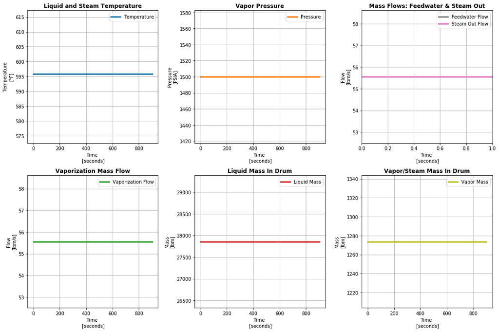

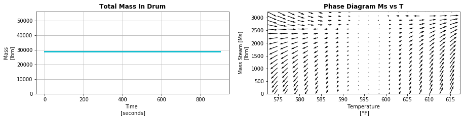

```python
# plot vars
n = 900 # number of data points
sec = 900. # number of seconds to simulate

t = np.linspace(0,sec,n) #Create Time Vector [secs]

# run simulation and calculate other vars
T,Ms = odeint(drumModel,[T0,Ms0],t,args=(Hfw,Mfw,Hfg,Mout)).T
T1,P1,Ms1,ML1,rho1,Mv1,Hs1 = calcSystem(T,Ms,Hfw,Mfw,Hfg,Mout)
Y = [t,T1,P1,Ms,ML1,rho1,Mv1,Hs1,Hfw,Mfw,Hfg,Mout]

# Plot this simulation
plotCase(Y)
```

#### Results for Case 1: Quiescent Operating Point

As expected, with the system in a stable and balanced operational point the flows, masses, temperature and pressure all remain static. This verifies the model is working in the balanced case. There is are nullclines at the expected current temperature of $\approx 596 °F$ but unexpectedly, another nullcline starting around $(570 °F, 2500 lbm)$ and curving gently to the point around $(610 °F, 3000 lbm)$. This makes sense, as for any given temperature, there would be a mass above which there is not enough energy to keep the vaporization flow high enough to replenish that which is lost via $\dot{M_{out}}$. Similarly, as the temperature increases the amount of energy in the system will be higher and simply convert all the mass to steam/vapor.

### Simulation Case 2: Negative Mass Imbalance

For this case, we examine the simulation with a mass imbalance induced by reducing the feedwater flow, $\dot{M_{FW}}$, to **90%** of $\dot{M_{out}}$. This will create a negative change in total mass to the boiler drum over time.

#### Calculate and Tabulate Initial Conditions for Case 2: Negative Mass Imbalance

```python
'''
=============================================
           Negative Mass Imbalance
===========================================
-Take Initial Pressure to be at 1500 psia
-Feed Water Temperature to be 210 deg F
-Steam out = 200,000 lb/hr
-Feed water flow = 0.9*Steam Out
- 45% of the drum is steam by volume
=============================================
'''

P0 = 1500. #initial drum pressure [psia]
T0 = T_of_P(P0)  # initial drum temperature [deg F]
FW_temp = 210. # Feedwater Temperature [deg F]

Mout = 200000./3600. # Steam Flow Out [lbm/s]
Mfw = 0.9*Mout           #  Feedwater flow [lbm/s]
Hfw = IAPWS97(T = F2K(FW_temp), x = LIQUID).h*KJKG2BTULB # Feedwater Specific Enthalpy [btu/lbm]
Hs0 = Hs(T0)
Hfg = (Hs0 - Hfw)*Mout  # Enthalpy Flow from furnace [btu/s]

Ms0 = P0*PSI2PSF*0.45*Vd/Rsteam/F2R(T0)   # Mass of Steam Initially [lbm]

units = ['PSIA','°F','lbm','btu/lbm','lbm/s','btu/s','lbm/s']
ind = ['P0','T0','Ms0','Hfw','Mfw','Hfg','Mout']

df = pd.DataFrame([P0,T0,Ms0,Hfw,Mfw,Hfg,Mout],index=ind,columns=['Value'])
df['Units'] = units
display('Case 2: Negative Mass Imbalance Parameters',df)
```

```
'Case 2: Negative Mass Imbalance Parameters'
```

|  | Value | Units |
| --- | --- | --- |
| P0 | 1500.000000 | PSIA |
| T0 | 595.838660 | °F |
| Ms0 | 1273.724450 | lbm |
| Hfw | 178.163918 | btu/lbm |
| Mfw | 50.000000 | lbm/s |
| Hfg | 55025.128314 | btu/s |
| Mout | 55.555556 | lbm/s |

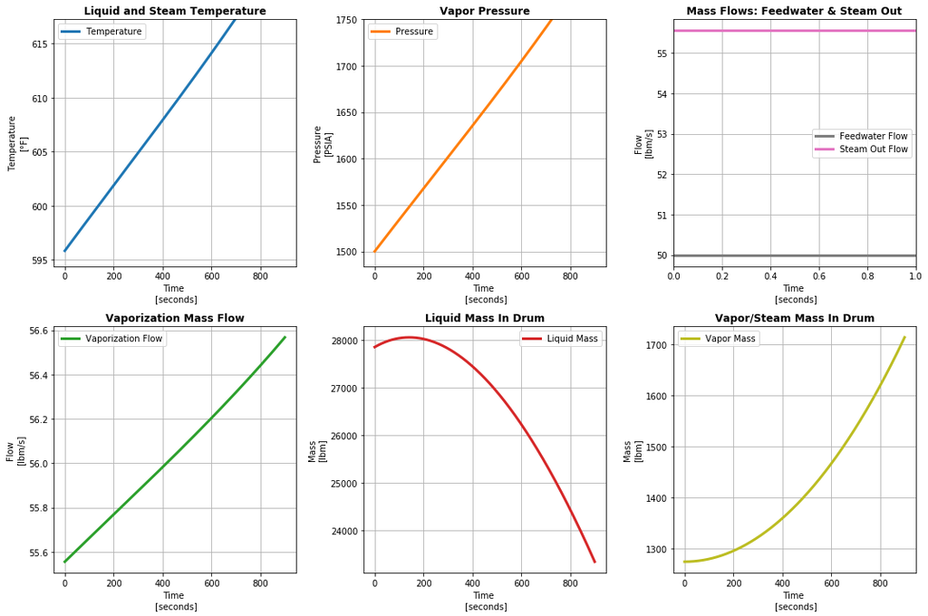

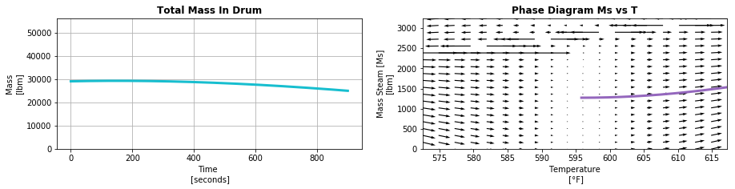

```python
# plot vars
n = 900 # number of data points
sec = 900. # number of seconds to simulate

t = np.linspace(0,sec,n) # Create Time Vector [secs]

# run simulation and calculate other vars
T,Ms = odeint(drumModel,[T0,Ms0],t,args=(Hfw,Mfw,Hfg,Mout)).T
T1,P1,Ms1,ML1,rho1,Mv1,Hs1 = calcSystem(T,Ms,Hfw,Mfw,Hfg,Mout)
Y = [t,T1,P1,Ms,ML1,rho1,Mv1,Hs1,Hfw,Mfw,Hfg,Mout]

# Plot this simulation
plotCase(Y)
```

#### Results for Case 2: Negative Mass Imbalance

Here we see the classic "swell" phenomenon. Even though the mass balance is negative, which intuitively should make the mass in the drum decrease, the dynamic response is initially in the opposite direction and followed by the reduction in liquid and total mass expected. Under these conditions, the temperature, pressure and vaporization flows respond linearly without reaching and equilibrium as expected, but the masses respond in a surprisingly nonlinear fashion. In a real boiler, the increase in drum pressure would cause the $\dot{M_{out}}$ to increase as well the result of which helps to suppress the "swell" phenomenon. Since $\dot{M_{out}}$ is held constant throughout the simulation, we can see the full effect in an isolated fashion.

### Simulation Case 3: Positive Mass Imbalance

For this case, we examine the simulation with a positive mass imbalance induced by increasing the feedwater flow, $\dot{M_{FW}}$, to **110%** of $\dot{M_{out}}$. This will create a positive change in total mass to the boiler drum over time.

#### Calculate and Tabulate Initial Conditions for Case 3: Positive Mass Imbalance

```python
'''
=============================================
        Positive Mass Imbalance
===========================================
-Take Initial Pressure to be at 1500 psia
-Feed Water Temperature to be 210 deg F
-Steam out = 200,000 lb/hr
-Feed water flow = 1.1*Steam Out
- 45% of the drum is steam by volume
=============================================
'''

P0 = 1500. #initial drum pressure [psia]
T0 = T_of_P(P0)  # initial drum temperature [deg F]
FW_temp = 210. # Feedwater Temperature [deg F]

Mout = 200000./3600. # Steam Flow Out [lbm/s]
Mfw = 1.1*Mout           #  Feedwater flow [lbm/s]
Hfw = IAPWS97(T = F2K(FW_temp), x = LIQUID).h*KJKG2BTULB # Feedwater Specific Enthalpy [btu/lbm]
Hs0 = Hs(T0)
Hfg = (Hs0 - Hfw)*Mout  # Enthalpy Flow from furnace [btu/s]

Ms0 = P0*PSI2PSF*0.45*Vd/Rsteam/F2R(T0)   # Mass of Steam Initially [lbm]

units = ['PSIA','°F','lbm','btu/lbm','lbm/s','btu/s','lbm/s']
ind = ['P0','T0','Ms0','Hfw','Mfw','Hfg','Mout']

df = pd.DataFrame([P0,T0,Ms0,Hfw,Mfw,Hfg,Mout],index=ind,columns=['Value'])
df['Units'] = units
display('Case 3: Positive Mass Imbalance Parameters',df)
```

```
'Case 3: Positive Mass Imbalance Parameters'
```

|  | Value | Units |
| --- | --- | --- |
| P0 | 1500.000000 | PSIA |
| T0 | 595.838660 | °F |
| Ms0 | 1273.724450 | lbm |
| Hfw | 178.163918 | btu/lbm |
| Mfw | 61.111111 | lbm/s |
| Hfg | 55025.128314 | btu/s |
| Mout | 55.555556 | lbm/s |

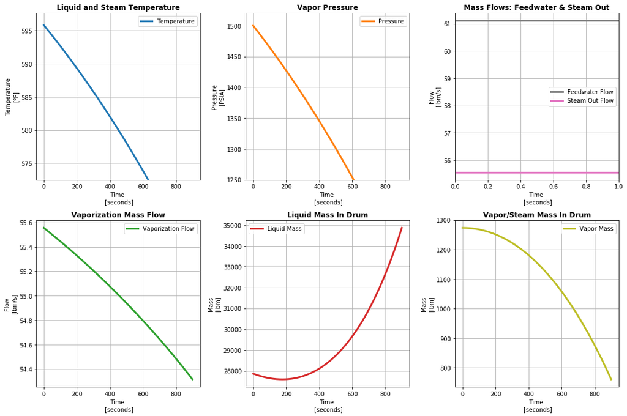

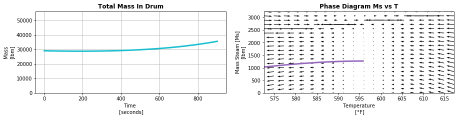

```python
# plot vars
n = 900 # number of data points
sec = 900. # number of seconds to simulate

t = np.linspace(0,sec,n) # Create Time Vector [secs]

# run simulation and calculate other vars
T,Ms = odeint(drumModel,[T0,Ms0],t,args=(Hfw,Mfw,Hfg,Mout)).T
T1,P1,Ms1,ML1,rho1,Mv1,Hs1 = calcSystem(T,Ms,Hfw,Mfw,Hfg,Mout)
Y = [t,T1,P1,Ms,ML1,rho1,Mv1,Hs1,Hfw,Mfw,Hfg,Mout]

# Plot this simulation
plotCase(Y)
```

#### Results for Case 3: Positive Mass Imbalance

Here we get another interesting result. The classic "shrink" phenomenon is evident as expected. The addition on extra mass to the system via the $\dot{M_{FW}}$ imbalance causes a nonlinear response in the direction opposite to intuition. After roughly 200 seconds, the liquid phase and total mass in the drum begin to rise following an initial reduction. Surprisingly, the temperature, pressure and vaporization flow are now slightly nonlinear with their derivative becoming more negative as time moves forward. Since the process is integrating in nature and the flows and energy sources, the system doesn't reach an equilibrium again as expected.

### Simulation Case 4: Negative Energy Imbalance

#### Calculate and Tabulate Initial Conditions for Case 4: Negative Energy Imbalance

```python
'''
=============================================
        Negative Energy Imbalance
===========================================
-Take Initial Pressure to be at 1500 psia
-Feed Water Temperature to be 210 deg F
-Steam out = 200,000 lb/hr
-Feed water flow = Steam Out
- 45% of the drum is steam by volume initially
- Enthalpy flow from the furnace is 95%
  of the equilibrium value
=============================================
'''

P0 = 1500. #initial drum pressure [psia]
T0 = T_of_P(P0)  # initial drum temperature [deg F]
FW_temp = 210. # Feedwater Temperature [deg F]

Mout = 200000./3600. # Steam Flow Out [lbm/s]
Mfw = Mout           #  Feedwater flow [lbm/s]
Hfw = IAPWS97(T = F2K(FW_temp), x = LIQUID).h*KJKG2BTULB # Feedwater Specific Enthalpy [btu/lbm]
Hs0 = Hs(T0)
Hfg = 0.95*(Hs0 - Hfw)*Mout  # Enthalpy Flow from furnace [btu/s]

Ms0 = P0*PSI2PSF*0.45*Vd/Rsteam/F2R(T0)   # Mass of Steam Initially [lbm]

units = ['PSIA','°F','lbm','btu/lbm','lbm/s','btu/s','lbm/s']
ind = ['P0','T0','Ms0','Hfw','Mfw','Hfg','Mout']

df = pd.DataFrame([P0,T0,Ms0,Hfw,Mfw,Hfg,Mout],index=ind,columns=['Value'])
df['Units'] = units
display('Case 4: Negative Energy Imbalance Parameters',df)
```

```
'Case 4: Negative Energy Imbalance Parameters'
```

|  | Value | Units |
| --- | --- | --- |
| P0 | 1500.000000 | PSIA |
| T0 | 595.838660 | °F |
| Ms0 | 1273.724450 | lbm |
| Hfw | 178.163918 | btu/lbm |
| Mfw | 55.555556 | lbm/s |
| Hfg | 52273.871899 | btu/s |
| Mout | 55.555556 | lbm/s |

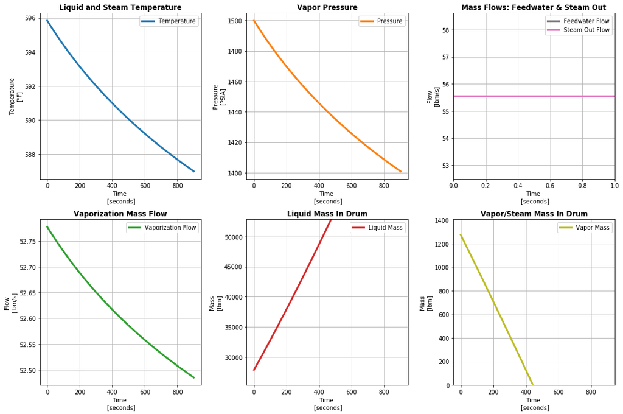

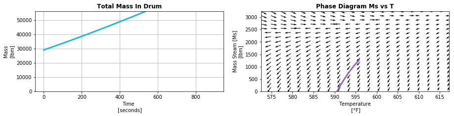

```python
# plot vars
n = 900 # number of data points
sec = 900. # number of seconds to simulate

t = np.linspace(0,sec,n) # Create Time Vector [secs]

# run simulation and calculate other vars
T,Ms = odeint(drumModel,[T0,Ms0],t,args=(Hfw,Mfw,Hfg,Mout)).T
T1,P1,Ms1,ML1,rho1,Mv1,Hs1 = calcSystem(T,Ms,Hfw,Mfw,Hfg,Mout)
Y = [t,T1,P1,Ms,ML1,rho1,Mv1,Hs1,Hfw,Mfw,Hfg,Mout]

# Plot this simulation
plotCase(Y)
```

#### Results for Case 4: Negative Energy Imbalance

In this simulation, the temperature, pressure and vaporization flows drop off in a slightly nonlinear fashion. We see that the results are again non-intuitive in the masses. A negative deficit in energy flow to the boiler drum produces a linear response with respect to the masses which would be expected for changes in mass balance, but instead occurs in response to energy balance. For the time frame selected, the vapor mass enters a negative region computationally. This is, of course, a loss of fidelity as the mass could not be negative. In this case, the boiler drum will eventually fill completely with liquid and carry over in to the steam delivery system.

### Simulation Case 5: Positive Energy Imbalance

For this case, we examine the simulation with a positive energy imbalance induced by increasing the enthalpy flow from the furnace, $\dot{H_{FG}}$, to **105%** of the calculated equilibrium value. This will create an increase in total energy flow to the boiler drum.

#### Calculate and Tabulate Initial Conditions for Case 5: Positive Energy Imbalance

```python
'''
=============================================
        Positive Energy Imbalance
===========================================
-Take Initial Pressure to be at 1500 psia
-Feed Water Temperature to be 210 deg F
-Steam out = 200,000 lb/hr
-Feed water flow = Steam Out
- 45% of the drum is steam by volume initially
- Enthalpy flow from the furnace is 105%
  of the equilibrium value
=============================================
'''

P0 = 1500. #initial drum pressure [psia]
T0 = T_of_P(P0)  # initial drum temperature [deg F]
FW_temp = 210. # Feedwater Temperature [deg F]

Mout = 200000./3600. # Steam Flow Out [lbm/s]
Mfw = Mout           #  Feedwater flow [lbm/s]
Hfw = IAPWS97(T = F2K(FW_temp), x = LIQUID).h*KJKG2BTULB # Feedwater Specific Enthalpy [btu/lbm]
Hs0 = Hs(T0)
Hfg = 1.05*(Hs0 - Hfw)*Mout  # Enthalpy Flow from furnace [btu/s]

Ms0 = P0*PSI2PSF*0.45*Vd/Rsteam/F2R(T0)   # Mass of Steam Initially [lbm]

units = ['PSIA','°F','lbm','btu/lbm','lbm/s','btu/s','lbm/s']
ind = ['P0','T0','Ms0','Hfw','Mfw','Hfg','Mout']

df = pd.DataFrame([P0,T0,Ms0,Hfw,Mfw,Hfg,Mout],index=ind,columns=['Value'])
df['Units'] = units
display('Case 5: Positive Energy Imbalance Parameters',df)
```

```
'Case 5: Positive Energy Imbalance Parameters'
```

|  | Value | Units |
| --- | --- | --- |
| P0 | 1500.000000 | PSIA |
| T0 | 595.838660 | °F |
| Ms0 | 1273.724450 | lbm |
| Hfw | 178.163918 | btu/lbm |
| Mfw | 55.555556 | lbm/s |
| Hfg | 57776.384730 | btu/s |
| Mout | 55.555556 | lbm/s |

```
'Final Simulation Values'
```

|  | Final Values [lbm] |
| --- | --- |
| Liquid | 1657.784327 |
| Vapor | 4787.473575 |
| Total Mass | 6445.257902 |

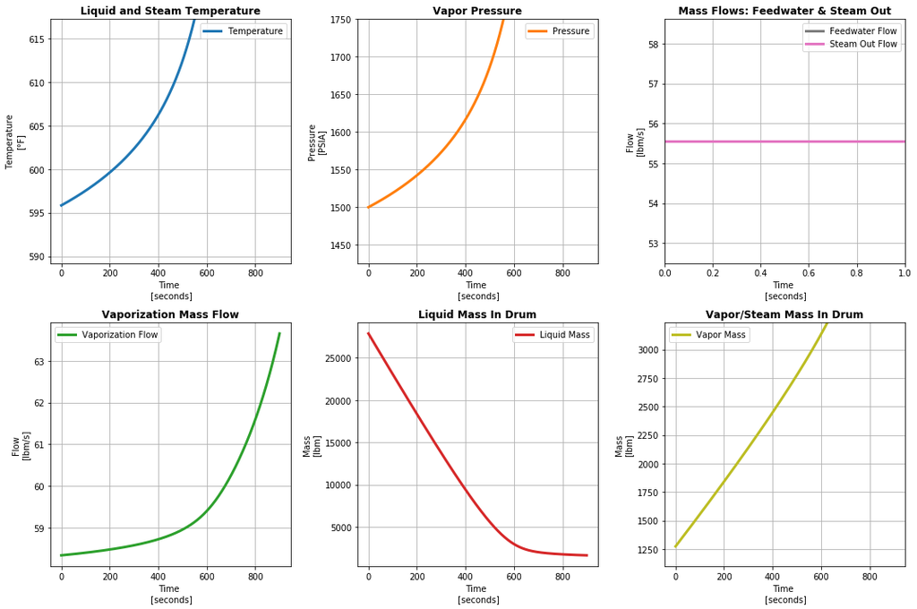

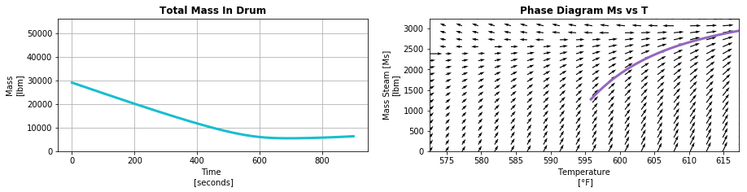

```python
# plot vars
n = 900 # number of data points
sec = 900. # number of seconds to simulate

t = np.linspace(0,sec,n) # Create Time Vector [secs]

# run simulation and calculate other vars
T,Ms = odeint(drumModel,[T0,Ms0],t,args=(Hfw,Mfw,Hfg,Mout)).T
T1,P1,Ms1,ML1,rho1,Mv1,Hs1 = calcSystem(T,Ms,Hfw,Mfw,Hfg,Mout)
Y = [t,T1,P1,Ms,ML1,rho1,Mv1,Hs1,Hfw,Mfw,Hfg,Mout]

# Plot this simulation
plotCase(Y)

# additional analysis
fv = pd.DataFrame([ML1[-1],Ms[-1],ML1[-1] + Ms[-1]],index=['Liquid','Vapor', 'Total Mass'],columns=['Final Values [lbm]'])
display('Final Simulation Values',fv)
```

## Conclusion

The model successfully shows the behavior of the "shrink and swell" phenomenon seen in practice. However, unlike real-world applications in which an increase or reduction in drum pressure would cause changes in the $\dot{M_{out}}$ flow that would help to counteract the phenomenon, we are able to see the full effect isolated from interaction.

This model could be expanded to include other effects on the system such as the introduction of an economizing heat exchanger model which would vary the $H_{FW}$ value with changes in mass flow and $\dot{H_{FG}}$ from the furnace section, and modeling the outlet of the steam drum as an orifice which would cause $\dot{M_{out}}$ to respond dynamically to changes in vessel pressure. In these cases, it is likely that equilibrium solutions would show up with proper design of the parameters due to their counteracting forces. Uses could include inverting the model to convert it in to a control rule for $\dot{M_{FW}}$ to better control difficult drum levels in a multivariate-nonlinear fashion. Additionally, creating multiple models linearizing various pressure regions could be synthesized to build a linear spline to further the model's application and validity.